# Introduction to corrgrapher

Paweł Morgen

Source: [`vignettes/Introduction.Rmd`](https://github.com/ModelOriented/corrgrapher/blob/master/vignettes/Introduction.Rmd)

## The problem

Data analysis (and creating models) involves many stages. For early exploration, it is useful to have a grip not only on individual series (AKA variables) available, but also on relations between them. Unfortunately, the task of understanding correlations between variables proves to be difficult ($n$ variables means $n(n-1) / 2$ pairs of variables). Furthermore, the mainstream method of visualizing them (i.e. correlation matrix) has its limits; the more variables, the less readable (and therefore meaningful) it becomes.

## Package `corrgrapher`

This package aims to plot correlations between variables in form of a graph. Variables correlated with each other shall be close (positively and negatively alike), and weakly correlated - far from each other.

It is achieved through a physical simulation, where the nodes are treated as points with mass (and are pushing each other away) and edges are treated as mass-less springs. The length of a spring depends on absolute value of correlation between connected nodes. The bigger the correlation, the shorter the spring.

## Example 1 - Seatbelts

Let’s take a look at one of datasets available in R - `Seatbelts`. It contains information about road casualties in Great Britain in 1969-84 period, and has following columns:

- `DriversKilled` - amount of car **drivers** killed
- `drivers` - amount of car **drivers** killed or seriously injured
- `front` - amount of **front-seat passengers** killed or seriously injured
- `rear` - amount of **rear-seat passengers** killed or seriously injured
- `kms` - distance driven
- `PetrolPrice` - petrol price
- `VanKilled` - number of van **drivers** killed.
- `law` - binary variable; was the law enforcing seatbelt use in effect?

For our purposes, since Pearson’s correlation index is irrelevant for binary variables, we drop the `law` variable.

```
library('corrgrapher')
df <- as.data.frame(datasets::Seatbelts)[,-8] # Drop the binary variable
cgr <- corrgrapher(df)
```

Thanks to implementation of `knit_print()` method, an object of class `corrgrapher` can be displayed simply by calling it:

```
cgr
```

[interactive chart not shown]

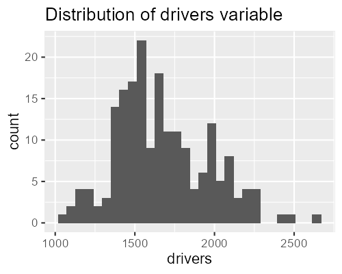

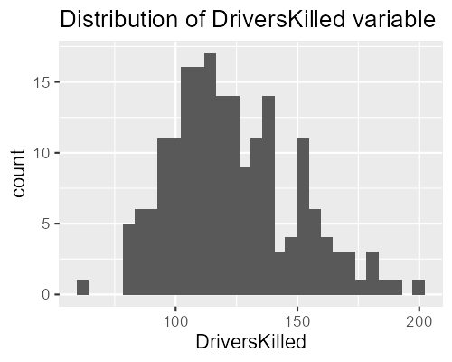

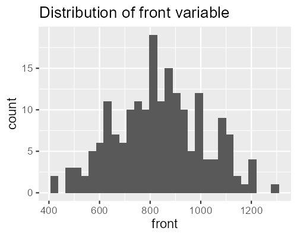

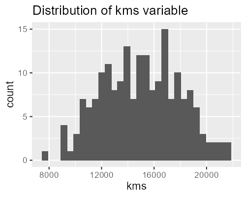

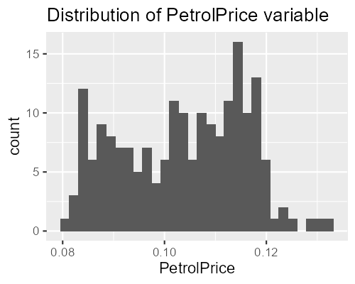

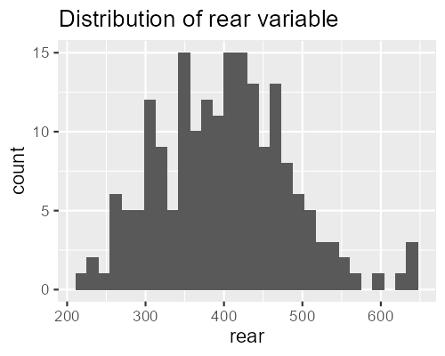

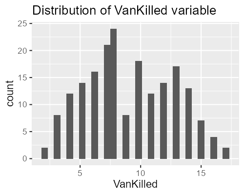

On the side a simple plot with distribution of variables is displayed. The figure is interactive - feel free to select a variable from a drag-drop selector or to click on the node.

As expected, we see, that all variables regarding casualties are correlated with each other, but `rear` and `VanKilled` weaker than others. We also observe the negative correlation between `PetrolPrice` and variables `drivers`, `DriversKilled` and `front`.

## Comparable correlation coefficients

Calculating comparable correlation coefficients between variables of different types (numerical - numerical, numerical - categorical, categorical - categorical) is a non-trivial problem. In this package, when encountering data with different kinds of variables, a following methodology is used:

1. First, the $p$-values are calculated of 3 different statistical tests:
- Pearson’s correlation test (`cor.test`) for 2 numerical variables
- Kruskal’s test (`kruskal.test`) for a numerical and categorical variable
- Chi-squared test (`chisq.test`) for 2 categorical variables
2. Then, the $-log_{10}(p)$ is calculated and treated as ma measure of correlation between variables. All results above 100 ($p$-value < $10^{-100}$) are treated as absolute correlation and their value is reduced to 100
3. Finally, results are scaled to fit inside $[0,1]$ .

## Example 2 - Titanic

Dataset with information about passengers of Titanic is a good example of dataset with both numerical (`age`, `fare`, `sibsp`, `parch`) and categorical(`gender`, `embarked`, `country`, `survived`) data. Let us build a model to predict, whether a passenger survived the sinking or not.

Here, let us introduce to a way of combining the `CorrGrapheR` package with packages from [DrWhyAI family](https://modeloriented.github.io/DrWhy/). The `CorrrapheR` function may take an `explainer` object (created with the help of `DALEX` package), extract the data from it, and add extra features to the displayed figure.

The visualization is enriched with:

- Incorporation of importance of variables for the output of the model, using the size of nodes. The bigger the nodes, the more important they are
- Partial dependency plots, displayed on the side.

```
library(ranger)
library(ingredients)
library(DALEX)
data("titanic_imputed", package='DALEX')
tit_model <- ranger(survived ~ ., data = titanic_imputed, num.trees = 100)
tit_model_exp <- explain(tit_model,
                         data = titanic_imputed[,-8],
                         y = titanic_imputed[, 8],
                         verbose = FALSE)
tit_cgr <- corrgrapher(tit_model_exp)
```

```
tit_cgr
```

[interactive chart not shown]

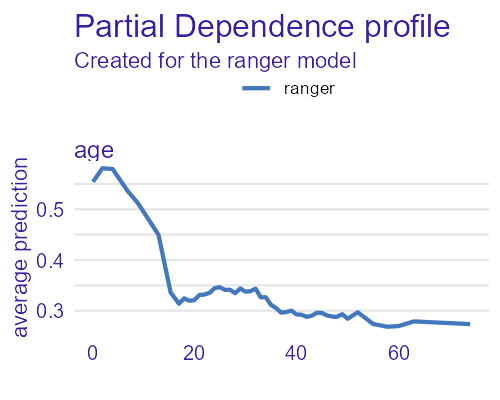

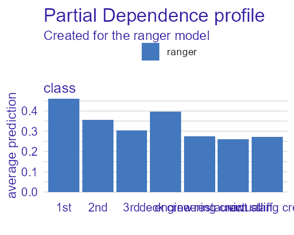

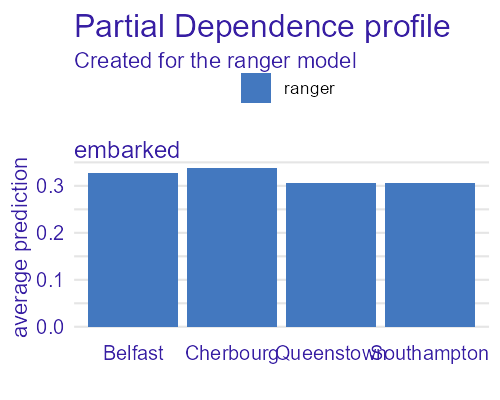

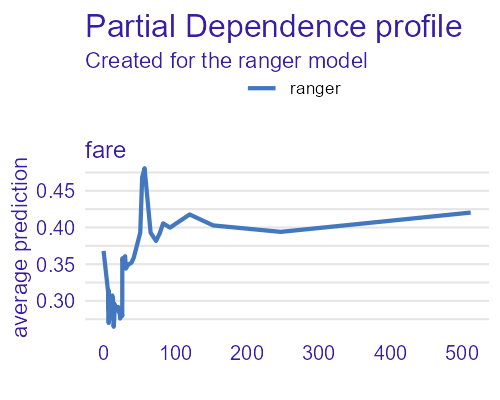

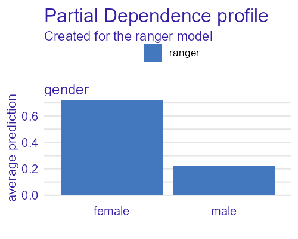

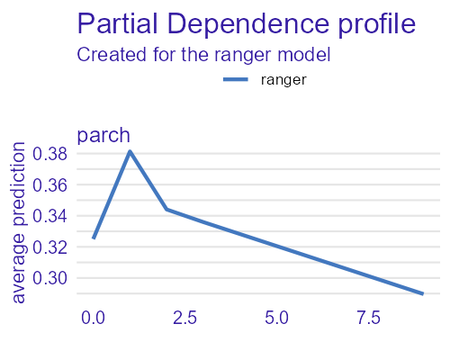

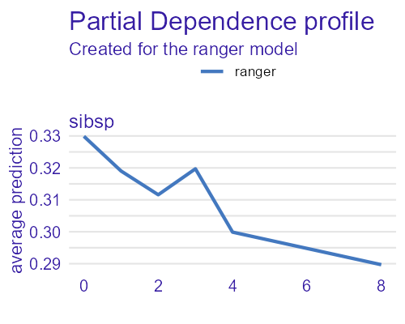

What can we learn from the figure:

- The most important variable is `gender` - women were given priority to access evacuation boats.
- Right after it are variables `class` (1st class was privileged) and `age` (children also were given priority during evacuation).
- We also see, that `fare` was an important variable, but it was **very** strongly connected to `class` variable - no surprise there.
- Surprisingly, `class` is strongly correlated with `gender` and `embarked`.
- Finally, `parch` (amount of parents/children aboard) and `sibsp`(amount of spouses/siblings abroad) are strongly connected. It would indicate, that traveling with whole family was a common occurance.

## Example 3 - FIFA

Let’s look at something more challenging to visualize. The dataset for FIFA 20 soccer game (more info [here](https://www.kaggle.com/stefanoleone992/fifa-20-complete-player-dataset) and [here](https://github.com/pbiecek/explainFIFA20)) contains 89 columns of data about soccer players from all around the world. Visualizing it is a non-trivial task.

For this use-case, let us create a model based on numerical variables (42 in total), that will predict the value in EUR of soccer players.

```
library("gbm")

library("readr")
fifa20 <- as.data.frame(read_csv("players_20.csv"))

fifa20_selected <- fifa20[,c(4,5,7,8,11:13,17,26,45:78)]

# Value is skewed. Will be much easier to model sqrt(Value).

fifa20_selected$value_eur <- log10(fifa20_selected$value_eur)
fifa20_selected <- na.omit(fifa20_selected)
fifa20_selected <- fifa20_selected[fifa20_selected$value_eur > 0,]
fifa20_selected <- fifa20_selected[!duplicated(fifa20_selected[,1]),]
rownames(fifa20_selected) <- fifa20_selected[,1]
fifa20_selected <- fifa20_selected[,-1]

# create a gbm model

set.seed(1313)

# 4:5 are overall and potential, too strong predictors
fifa_gbm <- gbm(value_eur ~ . , data = fifa20_selected[,-(4:5)], n.trees = 250, interaction.depth = 3)

# Create DALEX explainer

fifa_gbm_exp <- DALEX::explain(fifa_gbm,
                        data = fifa20_selected[, -6],
                        y = 10^fifa20_selected$value_eur,
                        predict_function = function(m,x)
                          10^predict(m, x, n.trees = 250))

fifa_feat <- ingredients::feature_importance(fifa_gbm_exp)
fifa_pd <- ingredients::partial_dependency(fifa_gbm_exp)
# Finally, create a corrgrapher object
fifa_cgr <- corrgrapher(fifa_gbm_exp, cutoff = 0.4,
                        feature_importance = fifa_feat,
                        partial_dependency = list(numerical = fifa_pd))
```

```
fifa_cgr
```

[interactive chart not shown]

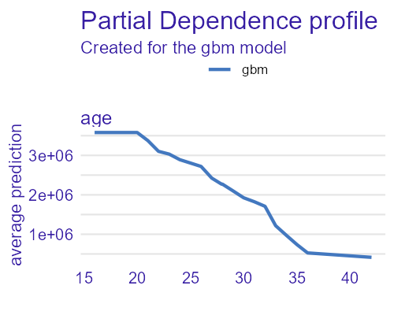

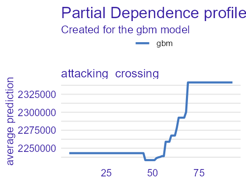

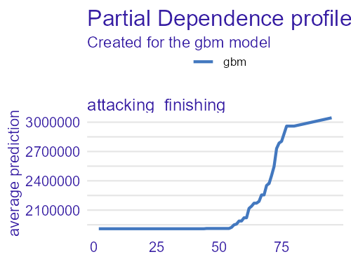

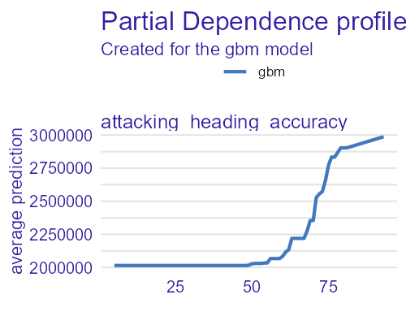

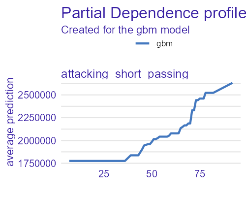

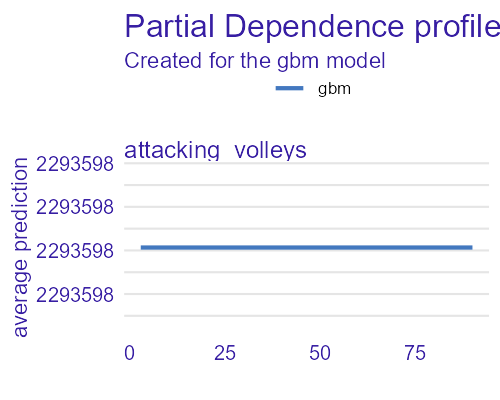

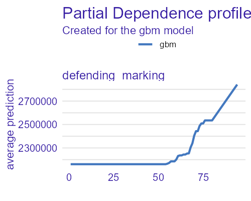

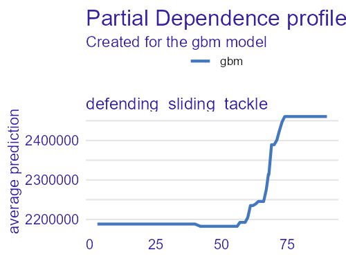

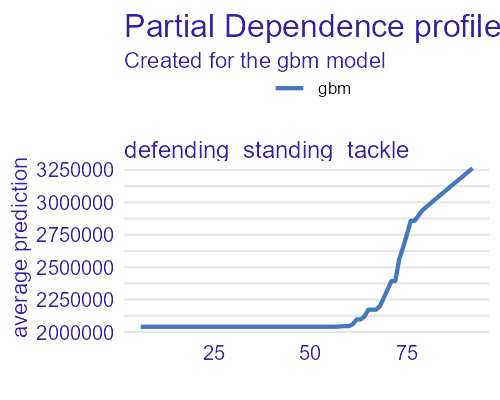

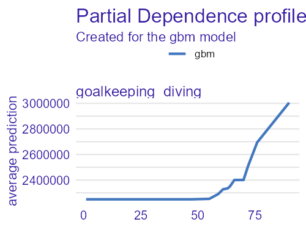

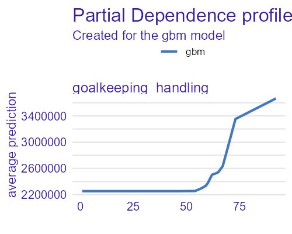

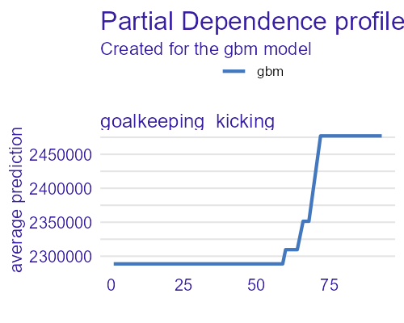

[29 more figures not shown]

What we can extract from the figure:

- The key variables are `movement_reactions`, `age`, `skill_ball_control`, `attacking_finishing` and `skill_dribling`
- The features containing goalkeepers’ skills are **very** highly correlated with each other and negatively correlated with the rest
- The features containing defenders’ skills are correlated with each other and with `mentality_interceptions`
- `movement_sprint_speed` is correlated with `movement_acceleration`
- …